# Supply Demand Gap Analysis

Josh Keffe, Stephan Monroe, Mark Oleson

2024-09-28

# 1 Purpose

The Purpose of this project is to provide background information to undergrad students, and to better understand of how saturated the labor market is for various degrees across the state of Ohio. Were you a student, this may be useful information in deciding what university program to enter and where to focus your skill development. As we only have access to public data, we will need to make some assumptions about supply by program, and demand by occupation. Namely, we are trusting the CIP-SOC crosswalk available on O*NET’s site, which aligns Classification of Instructional Programs (CIPs) with Standard Occupational Classifications (SOCs). Of course, not all students who graduate from a specific program will be hired into a crosswalked occupation, but this crosswalk gives us general links between students and where they are qualified to be hired, helping us understand how many graduates are competing for the same positions. Unemployed and transfers between occupations are also part of the supply pool, but we have limited the scope of this project to only include recent graduates.

# 2 Overview

The **Supply-Demand Gap Analysis** consists of two parts: the supply and the demand. Demand data, specifically **LMI predicted yearly job openings**, are used to map demand by occupation. For supply counts, we use IPEDS completers counts by CIP code. This RMarkdown outlines an attempt at modeling a supply demand gap analysis to help guide current student towards higher paying regions, and occupations with more demand relative to the number of graduates. This supply demand gap is calculated by dividing graduates sorted by **Classification of Instructional Programs (CIPs)** by job demand by **Standard Occupational Classifications (SOCs)**..

- **Supply Stock**: Represents the current available workforce for a given occupation or industry, including employed and unemployed individuals.
- **Supply Flow**: Represents the incoming workforce soon-to-be available, such as graduating students.

Data were updated to the most current versions and consolidated into tables. Specifically: - **IPEDS (Integrated Postsecondary Education Data System)** was updated through the academic year 2022, serving as the primary source for supply flow.

## 2.1 Data Overview

### 2.1.1 Supply Flow

- **IPEDS**: Publicly available at [IPEDS Website](https://nces.ed.gov/ipeds/), the list of CIPs includes all graduates in the state. Basic cleaning steps include:
  - Added new years of data up to 2022.
  - Standardized CIP codes and aggregated data by award level, program, and institution, then aggregating up to the JobsOhio region level and the state level.

### 2.1.2 Demand

- **LMI**: Long-term labor market information publicly available at [LMI Website](http://ohiolmi.com). Basic cleaning steps include:
  - Standardizing employment projections, occupational codes, and wage data format.

### 2.1.3 Data Structure

The counts by completers for the flow data source (IPEDS) are grouped as follows:

- **Year**: Aggregating data annually.
- **Graduating Program**: Using standardized CIP/SOC codes.
- **JobsOhio Region**: Adjustments based on zip code or county to JobsOhio region.
- **Education Classification**: Grouped into Certificate, Associate, Bachelor’s, and Graduate levels.

### 2.1.4 Geography

- Adjusted based on zip code to county to JobsOhio region, and were downloaded from the Ohio Department of Jobs and Family Services. The zip to county data was found from the two sources below: [HUD Office of Policy Development and Research](https://www.huduser.gov/) and [UnitedStatesZipCodes.org](https://www.unitedstateszipcodes.org/).

### 2.1.5 References

- **IPEDS**: [IPEDS Data Center](https://nces.ed.gov/ipeds/datacenter/)
- **OEWS**: [BLS OEWS](https://www.bls.gov/oes/)
- **LMI**: [Ohio LMI](http://ohiolmi.com/)
- **O*NET**: [O*NET Online](https://www.onetonline.org/)
- **Workforce Planning**: [Micheli, G. J. L., Martino, A., Porta, F., Cravello, A., Panaro, M., & Calabrese, A. (2023). Workforce planning in project-driven companies: a high-level guideline. *Frontiers in Industrial Engineering*, 1. https://doi.org/10.3389/fieng.2023.1267244

# 3 Data Import and Cleaning

```r
# This code reads the LMI jobs demand data by region and occupation from the ODJFS website.

#Paths
common_path <- getwd()
target_folder <- paste0(common_path, "/data/lmi-data/")

# Create the target folder, this will be helpful so all group members will automatically have a folder created
  dir.create(target_folder, recursive = TRUE)
# URLs for the different regions, these are all the excel sheets on the Ohio LMI website for each region.
# You can also simply go to each link and see the data.
url_northeast <- "https://ohiolmi.com/_docs/PROJ/JobsOhio/Northeast.xlsx"
url_central <- "https://ohiolmi.com/_docs/PROJ/JobsOhio/Central.xlsx"
url_west <- "https://ohiolmi.com/_docs/PROJ/JobsOhio/West.xlsx"
url_southeast <- "https://ohiolmi.com/_docs/PROJ/JobsOhio/Southeast.xlsx"
url_northwest <- "https://ohiolmi.com/_docs/PROJ/JobsOhio/Northwest.xlsx"
url_southwest <- "https://ohiolmi.com/_docs/PROJ/JobsOhio/Southwest.xlsx"



# Process Northeast region First
temp_northeast <- tempfile(fileext = ".xlsx")
response_northeast <- GET(url_northeast, write_disk(temp_northeast, overwrite = TRUE)) #Calls the url, trys to read the xlsx
  headers_northeast <- suppressMessages(read_excel(temp_northeast, range = cell_rows(3:6)))
  #Have to get rid of bad headers
  headers_northeast <- apply(headers_northeast, 2, function(x) paste(na.omit(x), collapse = " "))
  headers_northeast <- c(headers_northeast, "med wage symbol")
  data_northeast <- suppressMessages(read_excel(temp_northeast, skip = 5))
  #Skip the first 5 rows! all headers of white space.
  colnames(data_northeast) <- headers_northeast[1:12]
  #grab the names from only these headers
  rows_all_na_northeast <- rowSums(is.na(data_northeast)) == ncol(data_northeast)
  first_all_na_row_northeast <- which(rows_all_na_northeast)[1]
  data_northeast <- data_northeast[1:(first_all_na_row_northeast - 1), ]
  #that's annoying, but this should give us JUST the headers and not weird splits or missing headers.
  data_northeast$jobsohioregion <- "Northeast"


#OKAY, now do the same thing for all the other 5 regions, just paste the above and change the region name as appropriate. We could probably write a loop....
# Process Central region________________________________________________________
temp_central <- tempfile(fileext = ".xlsx")
response_central <- GET(url_central, write_disk(temp_central, overwrite = TRUE))
  headers_central <- suppressMessages(read_excel(temp_central, range = cell_rows(3:6)))
  headers_central <- apply(headers_central, 2, function(x) paste(na.omit(x), collapse = " "))
  headers_central <- c(headers_central, "med wage symbol")
  data_central <- suppressMessages(read_excel(temp_central, skip = 5))
  colnames(data_central) <- headers_central[1:12]
  rows_all_na_central <- rowSums(is.na(data_central)) == ncol(data_central)
  first_all_na_row_central <- which(rows_all_na_central)[1]
    data_central <- data_central[1:(first_all_na_row_central - 1), ]
  data_central$jobsohioregion <- "Central"



# Process West region_______________________________________________________________
temp_west <- tempfile(fileext = ".xlsx")
response_west <- GET(url_west, write_disk(temp_west, overwrite = TRUE))
  headers_west <- suppressMessages(read_excel(temp_west, range = cell_rows(3:6)))
  headers_west <- apply(headers_west, 2, function(x) paste(na.omit(x), collapse = " "))
  headers_west <- c(headers_west, "med wage symbol")
  data_west <- suppressMessages(read_excel(temp_west, skip = 5))
  colnames(data_west) <- headers_west[1:12]
  rows_all_na_west <- rowSums(is.na(data_west)) == ncol(data_west)
  first_all_na_row_west <- which(rows_all_na_west)[1]
    data_west <- data_west[1:(first_all_na_row_west - 1), ]
  data_west$jobsohioregion <- "West"



# Process Southeast region___________________________________________________________________
temp_southeast <- tempfile(fileext = ".xlsx")
response_southeast <- GET(url_southeast, write_disk(temp_southeast, overwrite = TRUE))
  headers_southeast <- suppressMessages(read_excel(temp_southeast, range = cell_rows(3:6)))
  headers_southeast <- apply(headers_southeast, 2, function(x) paste(na.omit(x), collapse = " "))
  headers_southeast <- c(headers_southeast, "med wage symbol")
  data_southeast <- suppressMessages(read_excel(temp_southeast, skip = 5))
  colnames(data_southeast) <- headers_southeast[1:12]
  rows_all_na_southeast <- rowSums(is.na(data_southeast)) == ncol(data_southeast)
  first_all_na_row_southeast <- which(rows_all_na_southeast)[1]
    data_southeast <- data_southeast[1:(first_all_na_row_southeast - 1), ]
  data_southeast$jobsohioregion <- "Southeast"


# Process Northwest region___________________________________________________________________________
temp_northwest <- tempfile(fileext = ".xlsx")
response_northwest <- GET(url_northwest, write_disk(temp_northwest, overwrite = TRUE))
  headers_northwest <- suppressMessages(read_excel(temp_northwest, range = cell_rows(3:6)))
  headers_northwest <- apply(headers_northwest, 2, function(x) paste(na.omit(x), collapse = " "))
  headers_northwest <- c(headers_northwest, "med wage symbol")
  data_northwest <- suppressMessages(read_excel(temp_northwest, skip = 5))
  colnames(data_northwest) <- headers_northwest[1:12]
  rows_all_na_northwest <- rowSums(is.na(data_northwest)) == ncol(data_northwest)
  first_all_na_row_northwest <- which(rows_all_na_northwest)[1]
    data_northwest <- data_northwest[1:(first_all_na_row_northwest - 1), ]
  data_northwest$jobsohioregion <- "Northwest"



# Process Southwest region____________________________________________________________________
temp_southwest <- tempfile(fileext = ".xlsx")
response_southwest <- GET(url_southwest, write_disk(temp_southwest, overwrite = TRUE))
  headers_southwest <- suppressMessages(read_excel(temp_southwest, range = cell_rows(3:6)))
  headers_southwest <- apply(headers_southwest, 2, function(x) paste(na.omit(x), collapse = " "))
  headers_southwest <- c(headers_southwest, "med wage symbol")
  data_southwest <- suppressMessages(read_excel(temp_southwest, skip = 5))
  colnames(data_southwest) <- headers_southwest[1:12]
  rows_all_na_southwest <- rowSums(is.na(data_southwest)) == ncol(data_southwest)
  first_all_na_row_southwest <- which(rows_all_na_southwest)[1]
    data_southwest <- data_southwest[1:(first_all_na_row_southwest - 1), ]
  data_southwest$jobsohioregion <- "Southwest"

# Combine all region data sets into a single data frame
lmi_oews <- bind_rows(data_northeast, data_central, data_west, data_southeast, data_northwest, data_southwest)
#OKAY! all Regions loaded.
```

```r
#Ohio overall data_____________________________________________________________________________
# Define the column names manually, including the new 'median_wage_symbol'. This is because I cannot get the same method as the regions to work for Ohio overall, ran out of time.
column_names <- c(
  "soc_code",                    # SOC Code
  "soc_lmi_title",               # Occupational Title
  "employment",                  # Employment* 2020 Annual
  "projected_2030",             # 2030 Projected
  "change_employment",          # Change in Employment 2020-2030
  "percent_change",             # Percent
  "annual_openings_growth",     # Annual Openings Growth
  "exits",                      # Exits
  "transfers",                  # Transfers
  "total_openings",             # Total
  "median_wage",                # Median Wage May 2021
  "median_wage_symbol",         # med wage symbol
  "Typical Education Needed for Entry",    # Not used in the select list
  "Work Experience in a Related Occupation",    # Not used in the select list
  "Typical On-The-Job Training Needed to Attain Competency" # Not used in the select list
)


# Read the data from the Excel file, skipping the first three rows. I could not get the url to read in the same way....so I just downloaded this one. https://view.officeapps.live.com/op/view.aspx?src=https%3A%2F%2Fohiolmi.com%2F_docs%2FPROJ%2FOhio%2FOccOH30.xlsx&wdOrigin=BROWSELINK
ohio_data <- read_excel(paste0("./data/lmi-data/OccOH30_raw.xlsx"),
                        sheet = "Occupational Detail", skip = 3, col_names = FALSE)
ohio_data <- as.data.frame(ohio_data)
# Assign the manually defined column names to the data, these are defined above
colnames(ohio_data) <- column_names
# Add a new column 'jobsohioregion' with all values set to 'Ohio', this will give us the same manually added data column as the previous region code-chunks
ohio_data <- ohio_data %>%
  mutate(jobsohioregion = 'Ohio')
```

```r
#Combine Ohio and Region Data___________________________________________________________________________
# Ensure consistent column names and types for `ohio_data_trimmed`
ohio_data_trimmed <- ohio_data %>%
  select(
    soc_code, soc_lmi_title, employment, projected_2030,
    change_employment, percent_change, annual_openings_growth,
    exits, transfers, total_openings, median_wage,
    median_wage_symbol, jobsohioregion
  ) %>%
  mutate(
    employment = as.numeric(employment),  # Convert to numeric
    change_employment = as.numeric(change_employment),
    median_wage = as.numeric(median_wage),
    projected_2030 = as.numeric(projected_2030),
    percent_change = as.numeric(percent_change),
    annual_openings_growth = as.numeric(annual_openings_growth),
    exits = as.numeric(exits),
    transfers = as.numeric(transfers),
    total_openings = as.numeric(total_openings)
  )
# Ensure column names and types match for `lmi_oews`
lmi_oews <- lmi_oews %>%
  rename(
    soc_code = `SOC Code`,
    soc_lmi_title = `Occupational Title`,
    employment = `Employment* 2020 Annual`,
    projected_2030 = `2030 Projected`,
    change_employment = `Change in Employment 2020-2030`,
    percent_change = `Percent`,
    annual_openings_growth = `Annual Openings Growth`,
    exits = `Exits`,
    transfers = `Transfers`,
    total_openings = `Total`,
    median_wage = `Median Wage May 2021`,
    median_wage_symbol = `med wage symbol`
  ) %>% mutate(
    employment = as.numeric(employment),  # Convert to numeric
    projected_2030 = as.numeric(projected_2030),
    change_employment = as.numeric(change_employment),
    percent_change = as.numeric(percent_change),
    annual_openings_growth = as.numeric(annual_openings_growth),
    exits = as.numeric(exits),
    transfers = as.numeric(transfers),
    total_openings = as.numeric(total_openings),
    median_wage = as.numeric(median_wage)
  )
# Ensure standardized column names for both data frames
colnames(ohio_data_trimmed) <- tolower(trimws(colnames(ohio_data_trimmed)))
colnames(lmi_oews) <- tolower(trimws(colnames(lmi_oews)))

# Combine the two datasets
ohio_region_lmi_data <- bind_rows(lmi_oews, ohio_data_trimmed)%>%
  mutate(
    jobsohioregion = case_when( #casewhen easiest in this case
      jobsohioregion == "Northwest" ~ 1L,
       jobsohioregion == "West" ~ 2L,
      jobsohioregion == "Southwest" ~ 3L,
      jobsohioregion == "Northeast" ~ 4L,
      jobsohioregion == "Central" ~ 5L,
      jobsohioregion == "Southeast" ~ 6L,
      jobsohioregion == "Ohio" ~ 39L, #ohio to 39, check this is true for all
      TRUE ~ NA_integer_  # For any unmatched regions, set to NA, should removed these or see why they occurred
     )
    )
#Will have to fix manual vs hourly wage data later on it looks like. Pay attention to the wage symbol.
#SAVE the data
rda_file_path <- paste0(target_folder, "ohio_region_lmi_data.rda") #rda's always better (I think?)
save(ohio_region_lmi_data, file = rda_file_path)
```

```r
# IPEDS Directory data ----- Check the Read_me file in the data folder for instructions on how to pull.
# https://nces.ed.gov/ipeds/use-the-data
# Get JOR codes to attach to the IPEDS directory data
load('data/cross-walks/jobsohioregions.rda')

ipeds_directory <- read_csv('data/ipeds-institution-detail/STATA_RV_7162021-493.zip') %>%
  left_join(jobsohioregions, by = c('countycd' = 'statefips')) %>%
  transmute(
    ipeds_code = unitid,
    institutionname = instnm,
    street_address = addr,
    city = city,
    state = stabbr,
    zip = zip,
    web_address = webaddr,
    regionId = jobsohioregion,
    lat = latitude,
    lng = longitud
  )

save(ipeds_directory, file = 'data/ipeds-institution-detail/ipeds_directory.rda')
```

```r
# IPEDS Data ----- Check the Read_me file in the data folder for instructions on how to pull.
# https://nces.ed.gov/ipeds/use-the-data

# label values cipcode         label_cipcode
# label define label_awlevel         15 "Degrees/certificates total"
# label define label_awlevel         12 "Degrees total", add
# label define label_awlevel         3 "Associate''s degree", add
# label define label_awlevel         5 "Bachelor''s degree", add
# label define label_awlevel         7 "Master''s degree", add
# label define label_awlevel         9 "Doctor''s degree", add
# label define label_awlevel         10 "First-professional degree", add
# label define label_awlevel         13 "Certificates below the bacculaureate total", add
# label define label_awlevel         1 "Award of less than 1 academic year", add
# label define label_awlevel         2 "Award of at least 1 but less than 2 academic years", add
# label define label_awlevel         4 "Award of at least 2 but less than 4 academic years", add
# label define label_awlevel         14 "Certificates above the bacculaureate total", add
# label define label_awlevel         6 "Postbaccalaureate certificate", add
# label define label_awlevel         8 "Post-master''s certificate", add
# label define label_awlevel         11 "First-professional certificate", add

#Using the above category definitions from the STATA file you can download from IPEDS, let's remap to levels
#so we actually know what is going on
ipeds_degree_remapping <- tribble(
  ~awlevel, ~degree_group_logord,
  '1',        1L,
  '2',        1L,
  '3',        2L,
  '4',        1L,
  '5',        3L,
  '6',        1L,
  '7',        4L,
  '8',        5L,    # grad certificate
  '9',        4L,
  '10',         4L,
  '11',         5L,    # grad certificate
  '12',       NA,    # subtotals
  '13',       NA,    # subtotals
  '14',       NA,    # subtotals
  '15',       NA,    # subtotals
  '17',         4L,
  '18',         4L,
  '19',         4L
)

# Read files, keep only 6-digit CIP, address some variable name changes (crace24/ctotalt)
# Using default character because it is easier to start from there, keep CIP codes correct,

#First, use list.files to find the .zip files that download from IPEDS, better to store them as .zip, because they are large. If we downloaded as the read_me, then we should only have Ohio in each zip file.
ipeds_completions <- list.files('data/ipeds-completions', '.*zip$', full.names = TRUE) %>%
  map_dfr(~ read_csv(., col_types = cols(.default = col_character()))) %>%
  filter(nchar(cipcode) == 7) %>%  # 7 because of the "." in the number, e.g. "15.0101"
  mutate(grads = as.integer(ctotalt)) %>% #this is the grads count column
  left_join(ipeds_degree_remapping, by = 'awlevel') %>%
  filter(!is.na(degree_group_logord) & grads > 0) %>% # drop subtotals and zero rows
  group_by(unitid, year, cipcode, degree_group_logord) %>%  # this is for combining majornum = 1 and majornum = 2...i.e we count both majors for supply. unitid is the institution.
  summarise(graduates = sum(grads), .groups = 'drop') %>%
  left_join(transmute(ipeds_directory, unitid = as.character(ipeds_code), regionId), by = 'unitid') %>%
  select(ipeds_code = unitid,
         cip_code = cipcode,
         degree_group_logord,
         academic_year = year,
         jobsohioregion = regionId,
         graduates)

save(ipeds_completions, file = 'data/ipeds-completions/ipeds_completions.rda')
```

## 3.1 Final Datasets Created:

ohio_region_lmi_data: Occupation demand dataset that includes six Ohio regions and statewide data (jobsohioregion coded numerically for each region).

Main Variables: -soc_code: Standard Occupational Classification code. -soc_lmi_title: Occupation title based on LMI. -employment: Employment count for 2020. -projected_2030: Projected employment count for 2030. -change_employment: Change in employment from 2020 to 2030. -percent_change: Percentage change in employment. -annual_openings_growth: Annual growth in job openings. -median_wage: Median wage in 2021. -jobsohioregion: Region identifier (1-6 for regions, 39 for Ohio).

ipeds_completions.rda: IPEDS completions data for institutions in Ohio, linked to LMI regions.

Main Variables: -ipeds_code: Unique identifier for institutions. -cip_code: Classification of Instructional Programs code for program areas. -degree_group_logord: Ordinal representation of degree levels (e.g., 1 for -certificates, 2 for associate degrees, 3 for bachelor’s degrees). -academic_year: Year of data collection. -jobsohioregion: Region identifier linked to LMI regions. -graduates: Number of graduates in a given program and year.

```r
#Adjust the yearly median wage to hourly from LMI
# Convert median wage from yearly to hourly if the symbol is "**". It's weird and there is probably
#a more efficient way to do this, but I am just using mutate and gsub for each case. If it is a yearly
#symbol, I am calculating hourly wage from yearly by assuming 2080 hours in the year.
lmi_oews <- ohio_region_lmi_data%>%
  mutate(jobsohioregion = as.character(jobsohioregion))%>%
  mutate(median_wage = gsub("[^0-9.]", "", median_wage))%>%
  mutate(median_wage_symbol = gsub("[^0-9.]", "", median_wage_symbol))%>%
  mutate(median_wage = as.numeric(median_wage)) %>%
  mutate(median_wage_symbol = trimws(median_wage_symbol))%>%
  mutate(
    median_wage = case_when(
       !is.na(median_wage_symbol) & median_wage_symbol == "**" ~ median_wage / 2080,# Convert from yearly to hourly for '**'
      !is.na(median_wage_symbol) & median_wage_symbol == "††" ~ median_wage / 2080, # Convert from statewide annual wage ('††')
      !is.na(median_wage_symbol) & median_wage_symbol == "†" ~ median_wage,# Statewide hourly wage ('†'), no conversion
      !is.na(median_wage_symbol) & median_wage_symbol == "▲" ~ NA_real_,  # Wage not available ('▲'), set to NA
      median_wage >= 1000 ~ median_wage / 2080, #final check for over $1000 an hour, we maybe should just remove these, but I am assuming they are yearly.
      TRUE ~ median_wage  # Keep as is for other cases
    )
  )
#run it and it looks like for our data, 96$ an hour is the max, makes sense. Those making much more #probably don't have a reported salary as such.I also know the sate suppresses data on very high income individuals, but that would not come up in the median wage anyways.

summary(lmi_oews$median_wage)
```

```
##    Min. 1st Qu.  Median    Mean 3rd Qu.    Max.    NA's
##   9.238  17.900  23.090  26.684  30.863  96.981      27
```

```r
# Combine and De-duplicate Graduate Data _______________________________________
graduates_data <- ipeds_completions%>%
  dplyr::filter(academic_year >= 2010) %>% #here, academic year is the regular school year, so around Sept-May. This just let's us avoid pre-2010 codes (in my mind, need to check this)
  mutate(academic_year = as.integer(academic_year), jobsohioregion = as.character(jobsohioregion))

#Aggregate Data by Region and State_____________________________________________
# Summarize graduates by region
graduates_regions <- graduates_data %>%
  group_by(jobsohioregion, cip_code, degree_group_logord, academic_year)%>%
  #this is a count of graduates for each program, for each degree type, for each region, for each year.
  summarise(graduates = sum(graduates, na.rm = TRUE), .groups = "drop")

# Summarize graduates for the entire state, so same as prior chunk, but for the state overall
graduates_statewide <- graduates_regions %>%
  group_by(cip_code, degree_group_logord, academic_year) %>%
  summarise(graduates = sum(graduates, na.rm = TRUE), .groups = "drop") %>%
  mutate(jobsohioregion = "39")

# Combine regional and statewide data
state_region_graduates <- bind_rows(graduates_regions, graduates_statewide)
rm(graduates_regions, graduates_statewide) #don't save the old versions
```

```r
#read in crosswalk and do second sheet, which is CIP-SOC
cip_soc <- read_excel("data/cross-walks/CIP2020_SOC2018_Crosswalk.xlsx", sheet = 'CIP-SOC')
soc_cip <- read_excel("data/cross-walks/CIP2020_SOC2018_Crosswalk.xlsx", sheet = 'SOC-CIP')


# Join Graduate Data with CIP-SOC Mappings____________________________________________________
#Standardize column names in both data sets
cip_soc <- cip_soc %>%
  mutate(cip_code = trimws(CIP2020Code))%>%
  mutate(soc_code = trimws(SOC2018Code))
soc_cip <- soc_cip %>%
  mutate(cip_code = trimws(CIP2020Code))%>%
  mutate(soc_code = trimws(SOC2018Code))

state_region_graduates <- state_region_graduates %>%
  mutate(cip_code = trimws(cip_code))

#Check for unmatched `cip_code` values before joining
unmatched_cip_codes <- setdiff(state_region_graduates$cip_code, cip_soc$cip_code)
print(unmatched_cip_codes)  # Check for missing or mismatched `cip_code` values
```

```
##  [1] "15.0503" "15.0505" "43.0106" "43.0111" "43.0116" "43.0117" "51.0808"
##  [8] "51.1104" "51.2501" "51.3817" "43.0118" "01.0309" "19.0000" "51.2101"
## [15] "51.2401" "51.1901"
```

```r
#merge the SOC codes into our graduate data, so we have counts by all CIP-SOC matchings. If we want to know the supply
# for a specific SOC, we can sum up the graduates grouped by soc, degree, year, region.
#IMPORTANT TO REMEMBER, AFTER THIS STEP THEY ARE NO LONGER UNIQUE COUNTS, BUT MUST BE INTERPRITED BY THEIR GROUPING OF cip-soc
aggregated_data <- state_region_graduates %>%
  mutate(cip_only_id = paste(cip_code, degree_group_logord, academic_year, jobsohioregion, sep = "_")) %>%
  left_join(cip_soc, by = c("cip_code" = "cip_code")) %>% #join in our SOC codes, most CIP codes match to multiple SOC codes, so the number of rows will increase. IT is important to conceptualize what is happening in this step.
    mutate(cip_code_soc_code_filter_groups_id = paste(cip_code, soc_code, degree_group_logord, academic_year, jobsohioregion, sep = "_")) %>% #This is to keep track of the groupings, we create a unique id.
  group_by(soc_code, cip_code, degree_group_logord, jobsohioregion, academic_year) %>%
  summarise(total_graduates = sum(graduates, na.rm = TRUE), .groups = "drop") %>%
  #For each CIP-SOC match-up, we have total-graduates.
   dplyr::select(cip_code, academic_year, jobsohioregion, degree_group_logord, total_graduates, soc_code)
nrow(aggregated_data)
```

```
## [1] 253591
```

```r
#As an exercise, summarize JUST by our unique id variable, and see if we get the same number of observations
# aggregated_dataII <- state_region_graduates %>%
#   mutate(cip_only_id = paste(cip_code, degree_group_logord, academic_year, jobsohioregion, sep = "_")) %>%
#   left_join(cip_soc, by = c("cip_code" = "cip_code")) %>%
#     mutate(cip_code_soc_code_filter_groups_id = paste(cip_code, soc_code, degree_group_logord, academic_year, jobsohioregion, sep = "_")) %>%
#   group_by(cip_code_soc_code_filter_groups_id) %>%
#   summarise(total_graduates = sum(graduates, na.rm = TRUE), .groups = "drop") %>%
#    select(cip_code_soc_code_filter_groups_id, total_graduates)
# nrow(aggregated_dataII)


# Calculate Total CIP Graduates per SOC, Region, and Degree Group ______________________________________________
total_cip_graduates_per_soc <- aggregated_data %>%
  group_by(soc_code, jobsohioregion, degree_group_logord, academic_year)%>%
   summarise(total_cip_graduates_by_soc = sum(total_graduates, na.rm = TRUE), .groups = "drop")%>%
  dplyr::filter(!is.na(jobsohioregion))
#So the graduate counts in this table represent all graduates in the same region, and academic year who are
#available to work in each occupation, separated by degree type.

# Merge total CIP graduates back with the main data
aggregated_data <- aggregated_data %>%
  left_join(total_cip_graduates_per_soc, by = c("soc_code", "jobsohioregion", "degree_group_logord", "academic_year"))

# Integrate LMI Data  ____________________________________________
aggregated_data_with_lmi <- aggregated_data %>%
  left_join(lmi_oews, by = c("soc_code", "jobsohioregion"))#the lmi_oews data applies to all years, we will just need to change the "employed" column to "employed 2020"
  # mutate(adjusted_demand = annual_openings_growth * (as.numeric(total_graduates) / as.numeric(total_cip_graduates_by_soc)))  I do not think the method of adjustment works.
```

```r
#lets do the gap ratio calculations
# Calculate Gap Ratio ________________________________________________________________________
master_aggregated_data <- aggregated_data_with_lmi%>%
  filter(degree_group_logord == 3)%>%#only keep bachelors for this analysis
  select(-degree_group_logord)%>%
  group_by(soc_code, jobsohioregion, academic_year)%>% #took off CIP code
  summarise(

                          ####GAP RATIO CALCULATION BELOW#####
         gap_ratio  = sum(total_graduates) / sum(annual_openings_growth, na.rm = TRUE),
                          ####################################

    # Preserve columns by taking their first occurrence. They are all the same, but I forget the correct way to tell R
    #this fact so they are preserved....
    total_cip_graduates_by_soc = first(total_cip_graduates_by_soc),
    total_graduates = first(total_graduates),
    employment = first(employment),
    annual_openings_growth = first(annual_openings_growth),
    median_wage = first(median_wage))%>%
  #And finally, rename the regions for our visualizations!
  mutate(jobsohioregion = case_when(
    jobsohioregion == '1' ~ 'Northwest',
    jobsohioregion == '2' ~ 'West',
    jobsohioregion == '3' ~ 'Southwest',
    jobsohioregion == '4' ~ 'Northeast',
    jobsohioregion == '5' ~ 'Central',
    jobsohioregion == '6' ~ 'Southeast',
    jobsohioregion == '39' ~ 'Ohio',
    TRUE ~ as.character(jobsohioregion)
  ))
```

# 4 Analysis

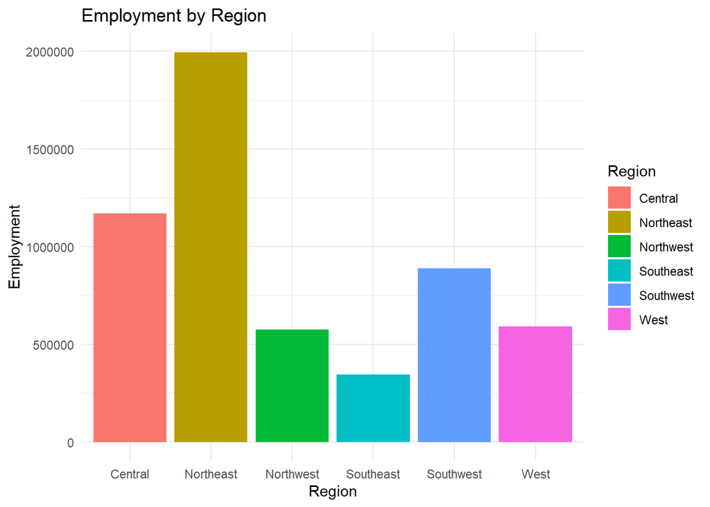

```r
ohio_region_lmi_data %>%
  mutate(jobsohioregion = case_when(
    jobsohioregion == '1' ~ 'Northwest',
    jobsohioregion == '2' ~ 'West',
    jobsohioregion == '3' ~ 'Southwest',
    jobsohioregion == '4' ~ 'Northeast',
    jobsohioregion == '5' ~ 'Central',
    jobsohioregion == '6' ~ 'Southeast',
    jobsohioregion == '39' ~ 'Ohio',
    TRUE ~ as.character(jobsohioregion))) %>%
  filter(jobsohioregion != "Ohio" & soc_lmi_title == "Total, All Occupations") %>%
  ggplot(aes(x = factor(jobsohioregion), y = employment, fill = jobsohioregion)) +
  geom_bar(stat = "identity", position = "dodge") +
  labs(title = "Employment by Region",
       x = "Region",
       y = "Employment",
       fill = "Region") +
  theme_minimal()
```

The above chart shows what the total employment is per region in Ohio. The northeast region has the most people employed. The southeast region has the lowest number of people employed.

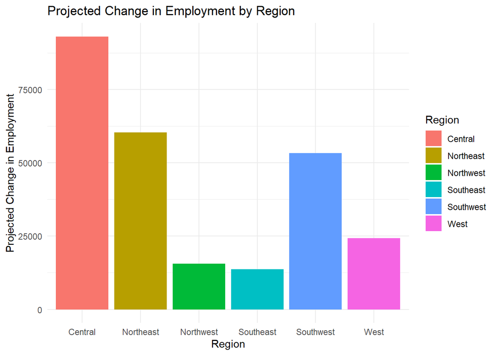

```r
ohio_region_lmi_data %>%
  mutate(jobsohioregion = case_when(
    jobsohioregion == '1' ~ 'Northwest',
    jobsohioregion == '2' ~ 'West',
    jobsohioregion == '3' ~ 'Southwest',
    jobsohioregion == '4' ~ 'Northeast',
    jobsohioregion == '5' ~ 'Central',
    jobsohioregion == '6' ~ 'Southeast',
    jobsohioregion == '39' ~ 'Ohio',
    TRUE ~ as.character(jobsohioregion))) %>%
  filter(jobsohioregion != "Ohio" & soc_lmi_title == "Total, All Occupations") %>%
  ggplot(aes(x = factor(jobsohioregion), y = change_employment, fill = jobsohioregion)) +
  geom_bar(stat = "identity", position = "dodge") +
  labs(title = "Projected Change in Employment by Region",
       x = "Region",
       y = "Projected Change in Employment",
       fill = "Region") +
  theme_minimal()
```

This chart shows the projected change in number of jobs in each region between now and 2030. All regions are projected to grow. The central will grow the most. The northwest and southeast will have the least, with the southeast being the lowest.

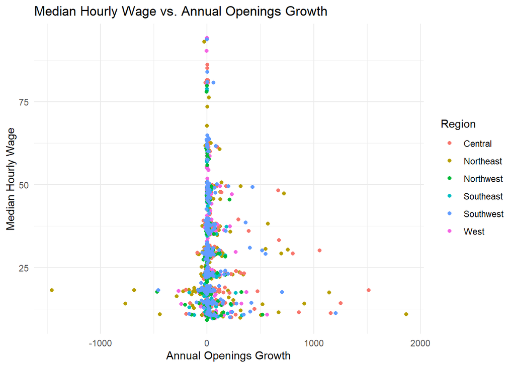

```r
lmi_oews %>%
  mutate(jobsohioregion = case_when(
    jobsohioregion == '1' ~ 'Northwest',
    jobsohioregion == '2' ~ 'West',
    jobsohioregion == '3' ~ 'Southwest',
    jobsohioregion == '4' ~ 'Northeast',
    jobsohioregion == '5' ~ 'Central',
    jobsohioregion == '6' ~ 'Southeast',
    jobsohioregion == '39' ~ 'Ohio',
    TRUE ~ as.character(jobsohioregion))) %>%
  filter(jobsohioregion != "Ohio" & soc_lmi_title != "Total, All Occupations") %>%
  ggplot(aes(x = annual_openings_growth, y = median_wage, color = factor(jobsohioregion))) +
  geom_point() +
  labs(title = "Median Hourly Wage vs. Annual Openings Growth",
       x = "Annual Openings Growth",
       y = "Median Hourly Wage",
       color = "Region") +
  theme_minimal()
```

This plot is a scatter that compares the annual jobs growth against what the median hourly wage is for that job. There doesn’t appear to be a trend between growth and wage. The majority of growth appears to be between an annual loss or gain of 500 jobs.

```r
lmi_oews %>%
  mutate(jobsohioregion = case_when(
    jobsohioregion == '1' ~ 'Northwest',
    jobsohioregion == '2' ~ 'West',
    jobsohioregion == '3' ~ 'Southwest',
    jobsohioregion == '4' ~ 'Northeast',
    jobsohioregion == '5' ~ 'Central',
    jobsohioregion == '6' ~ 'Southeast',
    jobsohioregion == '39' ~ 'Ohio',
    TRUE ~ as.character(jobsohioregion))) %>%
  filter(jobsohioregion != "Ohio" & soc_lmi_title != "Total, All Occupations") %>%
  filter(jobsohioregion == "Northeast" & (annual_openings_growth >= 1750 | annual_openings_growth <= -1000)) %>%
  select(soc_lmi_title, annual_openings_growth) %>%
  print()
```

```
## # A tibble: 2 × 2
##   soc_lmi_title                                    annual_openings_growth
##   <chr>                                                             <dbl>
## 1 Food Preparation and Serving Related Occupations                   1866
## 2 Office and Administrative Support Occupations                     -1457
```

Based on the previous plot, we could see that the most and least job growth was in the Northeast region. We could also tell that the growth was more than 1750 and the decrease was more than 1000. Using the region and annual growth, we can find that the largest growth was in the food prep and serving space and the largest decline was in the office and admin support space.

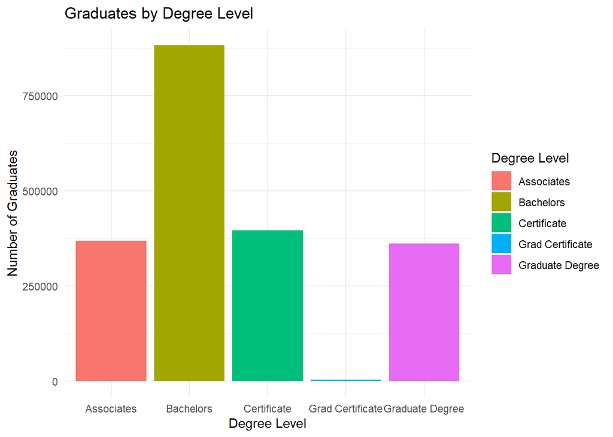

```r
ipeds_completions %>%
  mutate(degree_group_logord = case_when(
    degree_group_logord == 1 ~ 'Certificate',
    degree_group_logord == 2 ~ 'Associates',
    degree_group_logord == 3 ~ 'Bachelors',
    degree_group_logord == 4 ~ 'Graduate Degree',
    degree_group_logord == 5 ~ 'Grad Certificate')) %>%
  ggplot(aes(x = factor(degree_group_logord), y = graduates, fill = factor(degree_group_logord))) +
  geom_bar(stat = "identity") +
  labs(title = "Graduates by Degree Level",
       x = "Degree Level",
       y = "Number of Graduates",
       fill = "Degree Level") +
  theme_minimal()
```

This plot shows the number of graduates that have varying degrees. The largest degree is the bachelors and the lowest is the grad certificate. All other degrees have similar numbers of graduates across them.

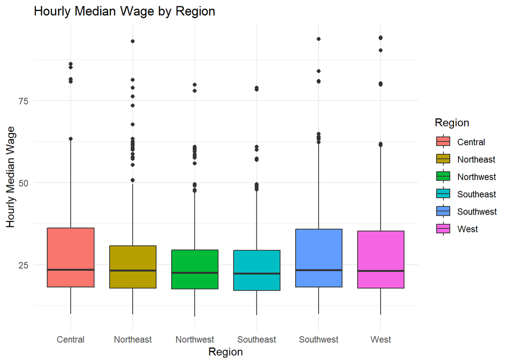

```r
lmi_oews %>%
  mutate(jobsohioregion = case_when(
    jobsohioregion == '1' ~ 'Northwest',
    jobsohioregion == '2' ~ 'West',
    jobsohioregion == '3' ~ 'Southwest',
    jobsohioregion == '4' ~ 'Northeast',
    jobsohioregion == '5' ~ 'Central',
    jobsohioregion == '6' ~ 'Southeast',
    jobsohioregion == '39' ~ 'Ohio',
    TRUE ~ as.character(jobsohioregion))) %>%
  filter(jobsohioregion != "Ohio" & soc_lmi_title != "Total, All Occupations") %>%
  ggplot(aes(x = factor(jobsohioregion), y = median_wage, fill = factor(jobsohioregion))) +
  geom_boxplot() +
  labs(title = "Hourly Median Wage by Region",
       x = "Region",
       y = "Hourly Median Wage",
       fill = "Region") +
  theme_minimal()
```

This plot is a box and whisker of hourly median wage and broken up by region. Each region appears to have around the same median wage. The Central, Southwest, and West appear to have similar 25th to 75th percentiles and the the Northeast, Northwest, Southeast have the same thing between them. Each region does have outlier median hourly wages.

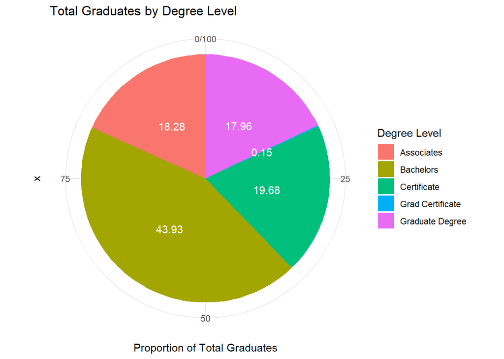

```r
total_graduates_by_degree <- ipeds_completions %>%
  mutate(degree_group_logord = case_when(
    degree_group_logord == 1 ~ 'Certificate',
    degree_group_logord == 2 ~ 'Associates',
    degree_group_logord == 3 ~ 'Bachelors',
    degree_group_logord == 4 ~ 'Graduate Degree',
    degree_group_logord == 5 ~ 'Grad Certificate')) %>%
  group_by(degree_group_logord) %>%
  summarise(total_graduates = sum(graduates, na.rm = TRUE)) %>%
  arrange(desc(total_graduates)) %>%
  mutate(prop = round(total_graduates / sum(total_graduates) *100, digits = 2))

ggplot(total_graduates_by_degree, aes(x = "", y = prop, fill = factor(degree_group_logord))) +
  geom_bar(stat = "identity", width = 1) +
  coord_polar("y", start = 0) +
  labs(title = "Total Graduates by Degree Level",
       fill = "Degree Level",
       y = "Proportion of Total Graduates") +
  geom_text(aes(label = prop),
            color = "white",
            position = position_stack(vjust = 0.5)) +
  theme_minimal()
```

#### 4.0.0.1 Quadrant Analysis

Finally, these dot plots map yearly job openings for associated SOC’s against the graduate counts for bachelor recipients by CIPs. The size of each dot is representative of the median wage, binned, compared to other occupations. The the dot’s color visualizes the gap ratio for each SOC code in Ohio, using only bachelor graduates from 2022. In this way, dots found in the top left quadrant are comparatively less saturated occupations for Ohio bachelor degree recipients in 2022. This could be used as a rough start for interested students to find their field of interest and associated CIP titles, and see where those titles fall in the quadrant, the size of the dot, and gap ratio (both by the dot’s position and color of the dot itself). This could be modified to apply to whichever JobsOhio region a college entrant may find themselves in.

Refer to the table for the top 3 occupations from each quadrant analysis. You can see the median wage in the table as well.

Once you find an occupation you may be interested in, check the CIP-SOC crosswalk for which CIP programs prepare you to enter that occupation.

```r
cips <- cip_soc%>%
  select(CIP2020Title, CIP2020Code)%>%
  unique()

socs <- soc_cip%>%
  select(SOC2018Code, SOC2018Title)%>%
  unique()

# Filter and Prepare the Data
filtered_data <- master_aggregated_data %>% #which is ONLY BACHELOR EARNERS
  filter(!is.na(gap_ratio)) %>%
  filter(jobsohioregion == "Ohio")%>% #want to do this on the state-level for now
  filter(academic_year == 2022)%>%
  # filter(gap_ratio > quantile(gap_ratio, 0.005) & gap_ratio < quantile(gap_ratio, 0.995)) %>% #easy way to remove outliers that we cannot dig into yet is to remove the first quantile, so a very small percentage.
  # left_join(cips, by = c("cip_code" = "CIP2020Code")) %>% #merge in the titles
      left_join(socs, by = c(  "soc_code" = "SOC2018Code"))%>%
mutate(
  graduates_ploted = round(ifelse(total_cip_graduates_by_soc > 0,
                                  log(total_cip_graduates_by_soc + 1), NA_real_), 2),
  log_yearly_postings = round(ifelse(annual_openings_growth > 0,
                                     log(annual_openings_growth + 1), NA_real_), 2),# Fix for NA's
    soc_group = substr(soc_code, 1, 2)) %>% #get the 2-digit SOC categories
  # filter(!is.na(CIP2020Title))%>%
filter(!is.na(log_yearly_postings))  # Remove titles that did not make it into 2020
  # filter(graduates_ploted > 5)

# Deduplicate the data before selecting observations, then select only the variables we need to keep
deduplicated_data <- filtered_data %>%
  select(SOC2018Title, median_wage, graduates_ploted, log_yearly_postings, soc_group, soc_code, jobsohioregion) %>%
  distinct()#okay good, this did not remove any rows, so we did not mess up at least in our grouping recently.

# Select top 3 observations for each CIP group
top_left_observations <- deduplicated_data %>%
  group_by(soc_group) %>% #this is the 2 digit CIP group we created earlier, representative of a larger category of CIP codes. such as "Physcial Sciences" which is the two digit code '40' and represents all physcial science programs, see :https://nces.ed.gov/ipeds/cipcode/cipdetail.aspx?y=55&cipid=88479
  arrange(soc_group, graduates_ploted, desc(log_yearly_postings)) %>%  # Sort by minimum graduates and maximum postings
  slice_head(n = 3) %>%  # Select the top 3 per group
  ungroup() %>%
  mutate( #Make sure all are rounded for cleaner table
    graduates_ploted = round(graduates_ploted, 2),
    log_yearly_postings = round(log_yearly_postings, 2),
    median_wage = round(median_wage, 2)
  ) %>%
  select(soc_group, SOC2018Title, graduates_ploted, log_yearly_postings, median_wage)

# Print the final table with  smaller text size and limit on decimal places. Use Kable!
kable(top_left_observations,
        format = "html",
        caption = "Top-left Observations for Each SOC Group",
        digits = 2
  ) %>%
    kable_styling(bootstrap_options = "striped", font_size = 12, position = "center")
```

Top-left Observations for Each SOC Group

| soc_group | SOC2018Title | graduates_ploted | log_yearly_postings | median_wage |
| --- | --- | --- | --- | --- |
| 11 | Education and Childcare Administrators, Preschool and Daycare | 3.33 | 3.18 | 22.31 |
| 11 | Education Administrators, Postsecondary | 3.33 | 1.95 | 45.68 |
| 11 | Education Administrators, All Other | 3.43 | 2.40 | 36.22 |
| 13 | Credit Counselors | 4.03 | 1.61 | 23.56 |
| 13 | Training and Development Specialists | 6.28 | 4.77 | 23.76 |
| 13 | Compliance Officers | 7.00 | 3.87 | 30.51 |
| 15 | Computer User Support Specialists | 4.04 | 4.62 | 22.96 |
| 15 | Operations Research Analysts | 5.20 | 4.68 | 40.91 |
| 15 | Actuaries | 5.66 | 3.56 | 47.88 |
| 17 | Environmental Engineering Technologists and Technicians | 2.08 | 1.39 | 22.83 |
| 17 | Surveyors | 3.14 | 0.69 | 29.34 |
| 17 | Petroleum Engineers | 3.58 | 1.79 | 48.15 |
| 19 | Food Scientists and Technologists | 3.04 | 1.39 | 40.47 |
| 19 | Epidemiologists | 3.95 | 2.20 | 36.60 |
| 19 | Occupational Health and Safety Specialists | 4.03 | 3.22 | 37.43 |
| 21 | Rehabilitation Counselors | 3.04 | 4.37 | 18.42 |
| 21 | Social and Human Service Assistants | 3.95 | 5.32 | 17.67 |
| 21 | Community and Social Service Specialists, All Other | 4.14 | 2.89 | 22.82 |
| 23 | Lawyers | 1.10 | 4.95 | 49.18 |
| 23 | Arbitrators, Mediators, and Conciliators | 2.94 | 1.39 | 24.59 |
| 23 | Paralegals and Legal Assistants | 4.03 | 4.61 | 22.57 |
| 25 | Instructional Coordinators | 2.94 | 3.69 | 29.83 |
| 25 | Career/Technical Education Teachers, Secondary School | 3.47 | 3.43 | 36.96 |
| 25 | Law Teachers, Postsecondary | 3.97 | 1.10 | 56.25 |
| 27 | Audio and Video Technicians | 0.69 | 3.47 | 22.08 |
| 27 | Sound Engineering Technicians | 2.89 | 0.69 | 22.13 |
| 27 | Camera Operators, Television, Video, and Film | 4.41 | 1.10 | 18.22 |
| 29 | Veterinary Technologists and Technicians | 0.69 | 3.71 | 17.48 |
| 29 | Occupational Therapists | 2.08 | 4.42 | 38.47 |
| 29 | Cardiovascular Technologists and Technicians | 2.20 | 2.71 | 29.47 |
| 31 | Veterinary Assistants and Laboratory Animal Caretakers | 0.69 | 3.81 | 14.22 |
| 31 | Healthcare Support Workers, All Other | 6.27 | 2.64 | 18.11 |
| 33 | Firefighters | 2.71 | 4.41 | 24.37 |
| 33 | First-Line Supervisors of Firefighting and Prevention Workers | 3.66 | 2.20 | 37.42 |
| 33 | Private Detectives and Investigators | 3.93 | 2.30 | 23.45 |
| 35 | First-Line Supervisors of Food Preparation and Serving Workers | 1.39 | 6.51 | 15.65 |
| 35 | Cooks, Institution and Cafeteria | 1.39 | 3.97 | 14.23 |
| 37 | Landscaping and Groundskeeping Workers | 1.10 | 4.80 | 14.58 |
| 39 | Childcare Workers | 2.89 | 4.62 | 11.17 |
| 39 | Animal Trainers | 3.56 | 2.56 | 14.24 |
| 39 | Morticians, Undertakers, and Funeral Arrangers | 3.83 | 1.61 | 29.44 |
| 41 | Sales Representatives of Services, Except Advertising, Insurance, Financial Services, and Travel | 1.10 | 5.16 | 25.14 |
| 41 | Parts Salespersons | 1.10 | 3.78 | 14.41 |
| 41 | Sales Representatives, Wholesale and Manufacturing, Technical and Scientific Products | 1.10 | 3.22 | 49.71 |
| 43 | Eligibility Interviewers, Government Programs | 1.39 | 2.40 | 22.40 |
| 43 | Proofreaders and Copy Markers | 7.01 | 0.69 | 18.36 |
| 45 | First-Line Supervisors of Farming, Fishing, and Forestry Workers | 5.69 | 1.61 | 28.56 |
| 49 | First-Line Supervisors of Mechanics, Installers, and Repairers | 6.25 | 4.38 | 31.22 |
| 51 | First-Line Supervisors of Production and Operating Workers | 6.25 | 4.45 | 29.48 |
| 53 | Commercial Pilots | 2.40 | 1.79 | 57.48 |
| 53 | Airline Pilots, Copilots, and Flight Engineers | 2.40 | 1.61 | 96.98 |
| 53 | Traffic Technicians | 2.40 | 0.69 | 28.78 |

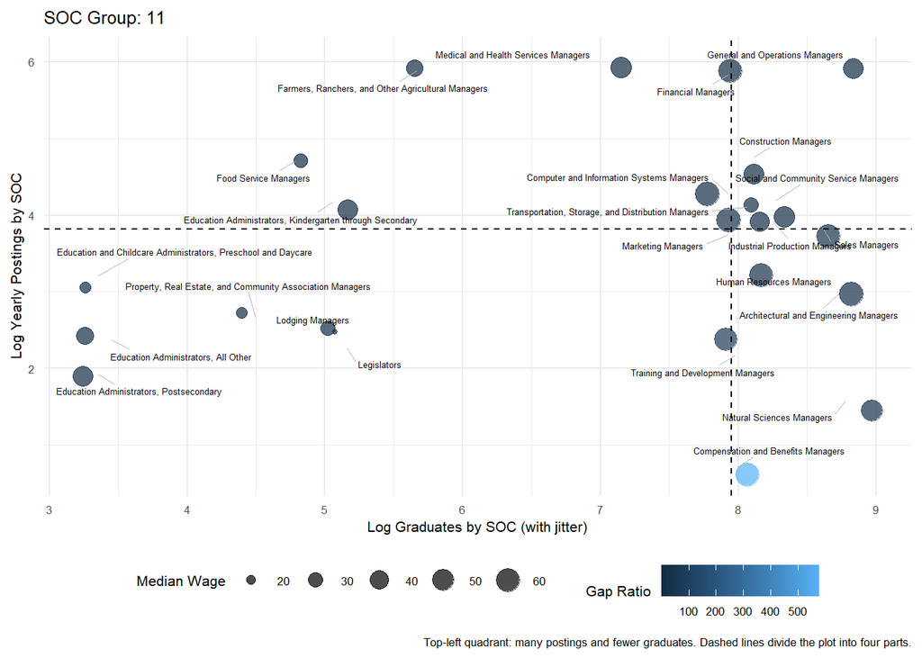

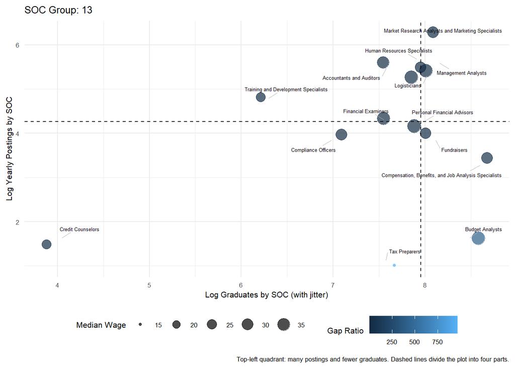

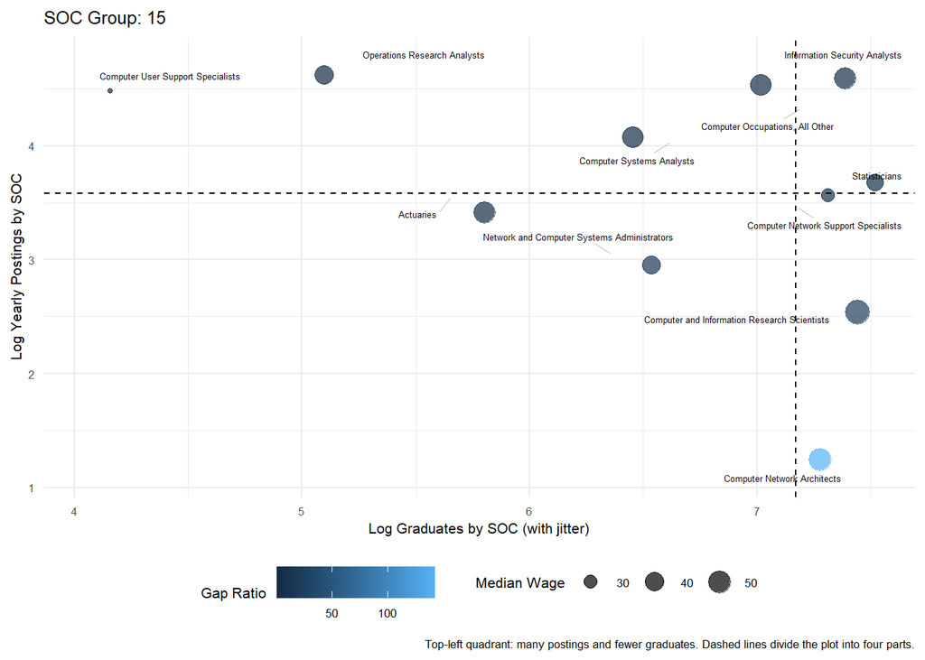

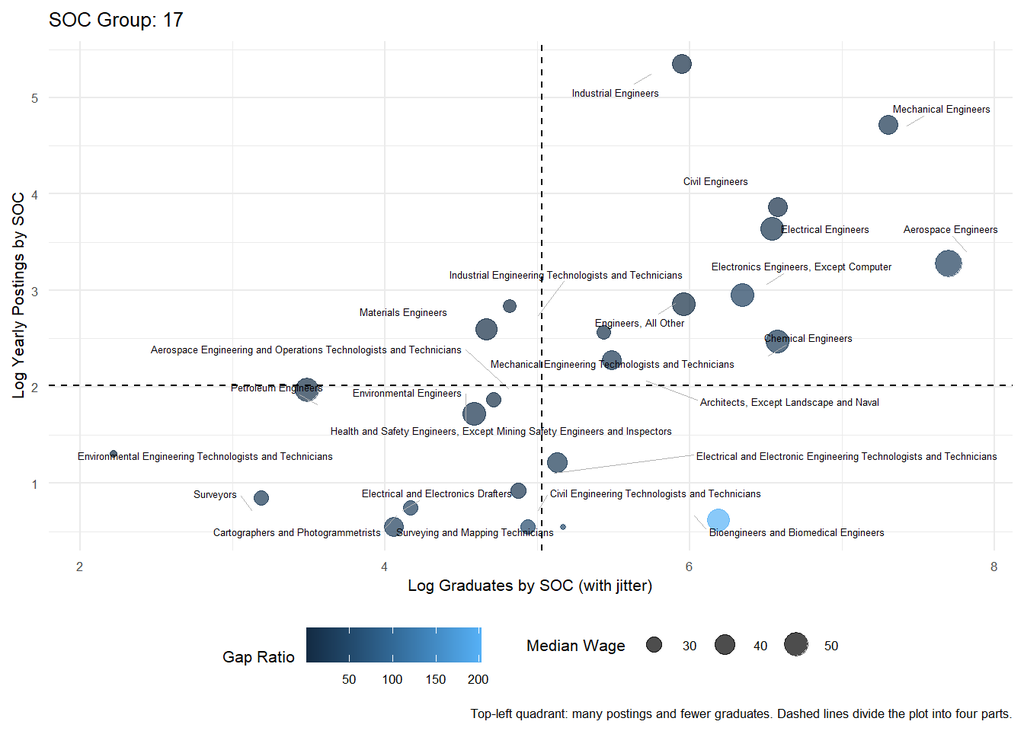

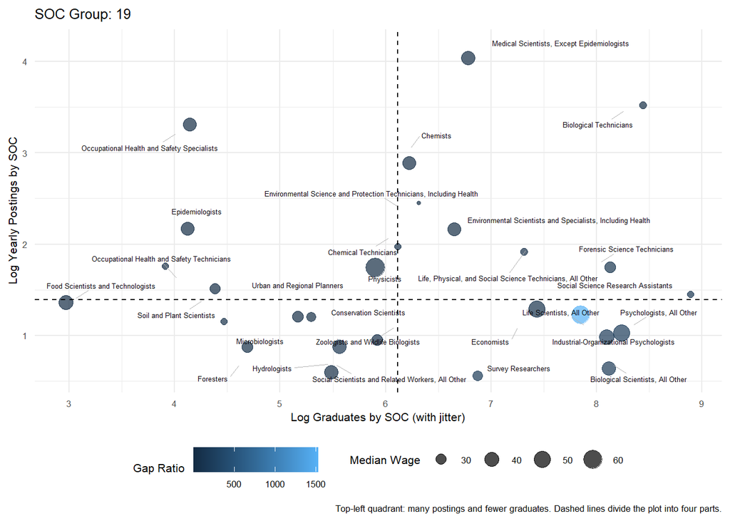

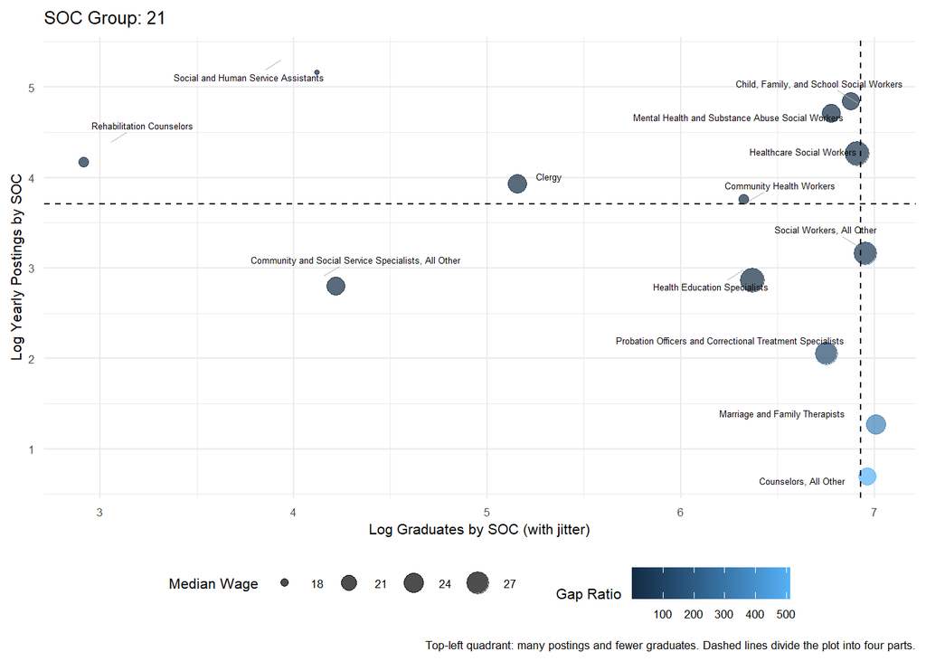

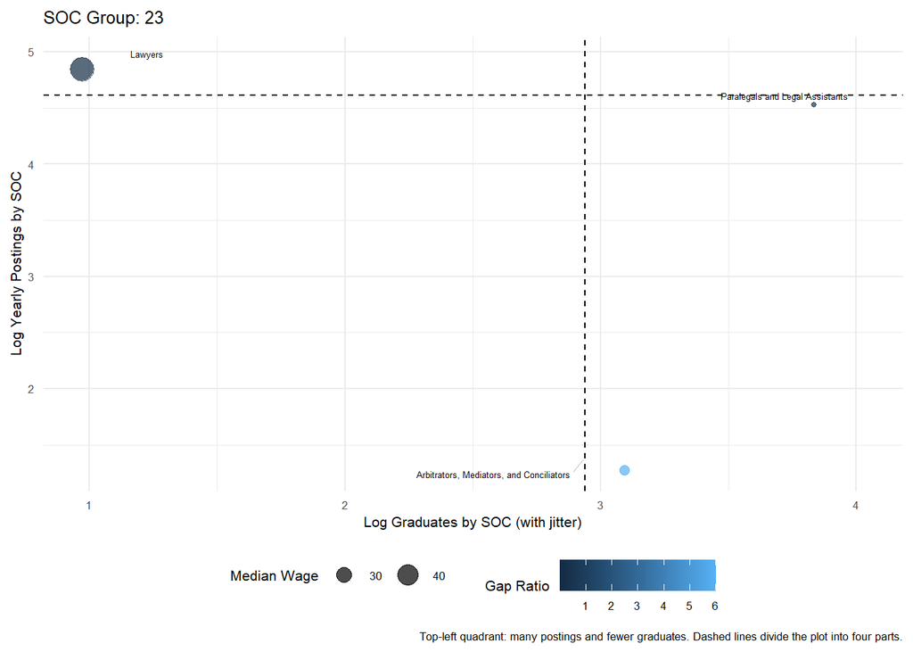

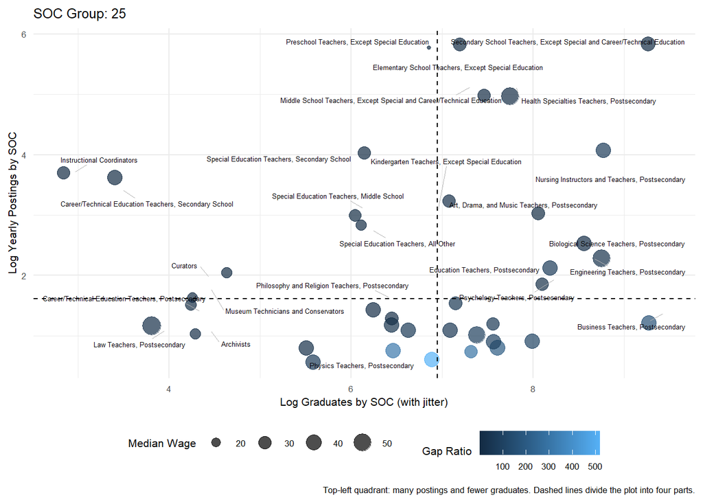

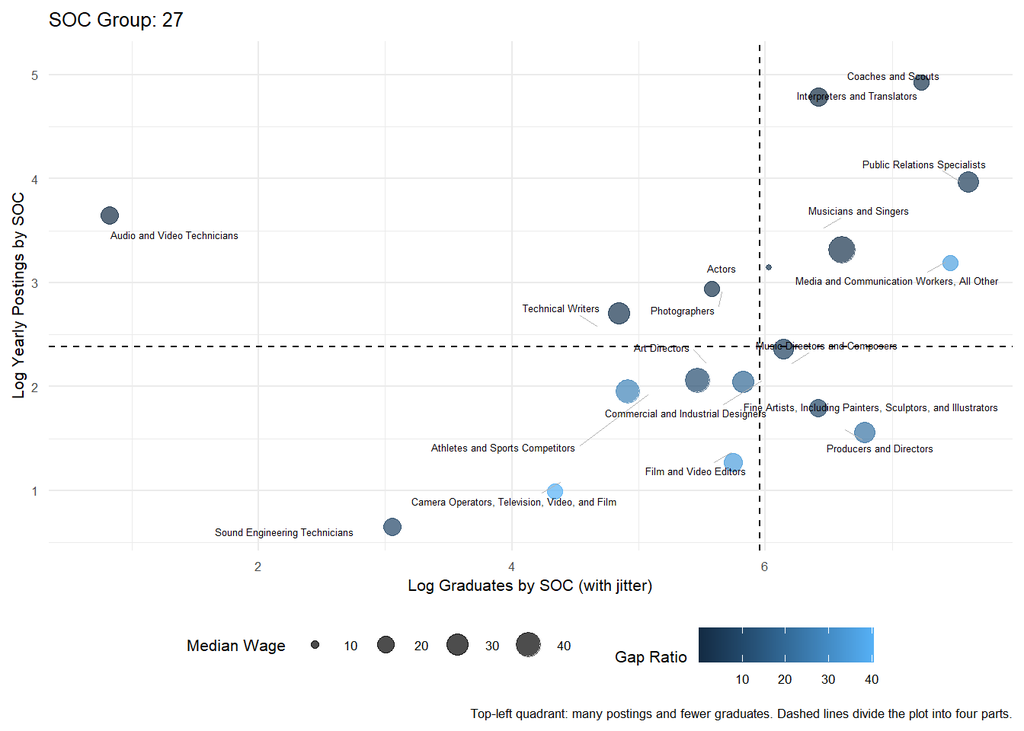

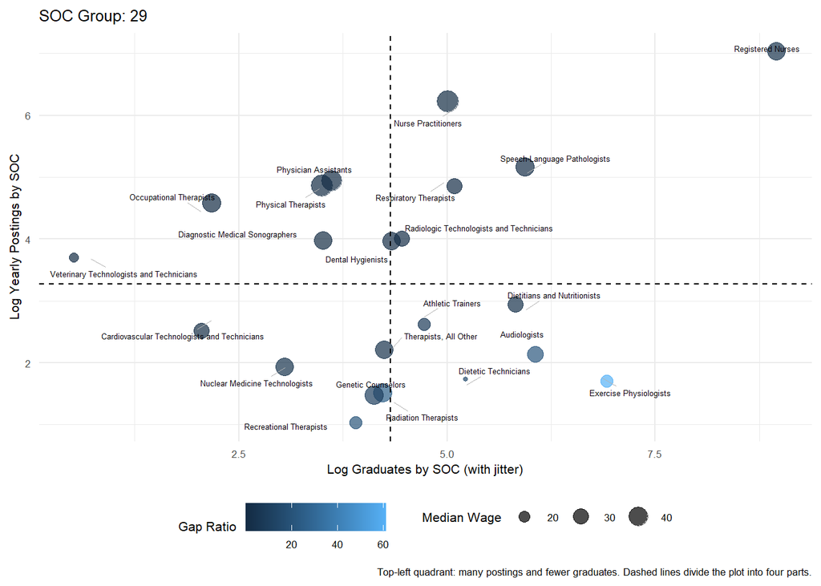

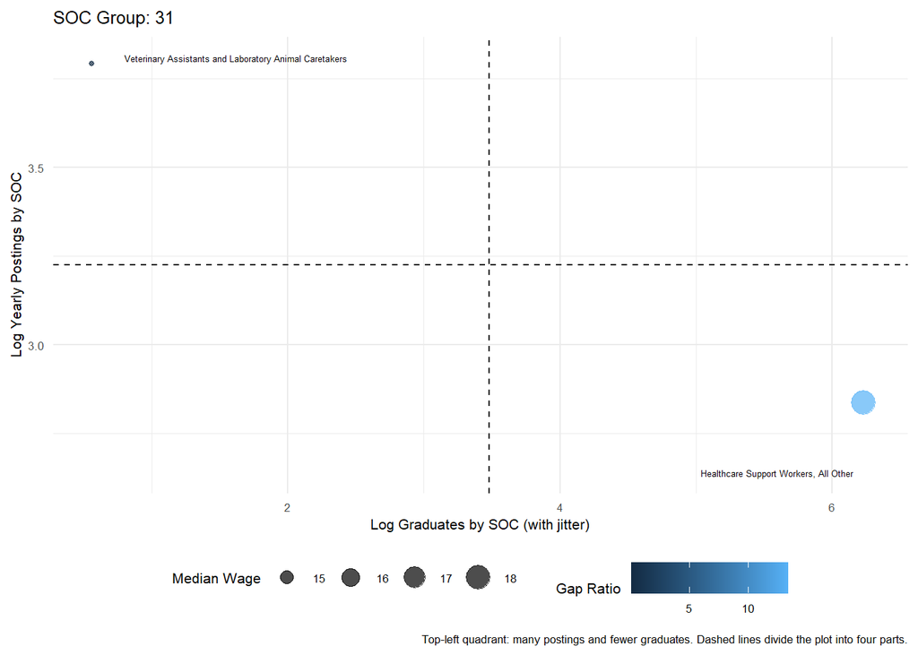

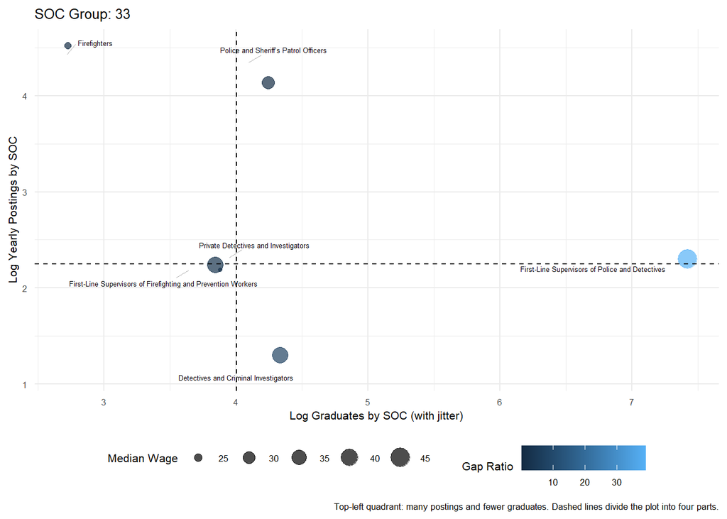

[9 more figures not shown]

```r
# Create Dot Plot for Each CIP Group, save this as a function first, then run for each group.
#In theory, we can create many many different starting data sets for different regions or other breakdowns and just
#apply this
##KEEP IN MIND, every dot is a specific SOC-CIPs grouping, so one-SOC and every matching CIP.

create_dotplot <- function(data) {
  # Calculate medians for horizontal and vertical lines
  median_x <- median(data$graduates_ploted, na.rm = TRUE)
  median_y <- median(data$log_yearly_postings, na.rm = TRUE)

  # Create the ggplot with SOC2018Title labels
  ggplot(data, aes(x = graduates_ploted, y = log_yearly_postings, color = gap_ratio, size = median_wage)) +
    geom_point(alpha = 0.7, position = position_jitter(width = 0.2, height = 0.2)) +

    # Add text labels using ggrepel!, pretty cool, just type ?ggrepel to get the gist. other examples: https://ggrepel.slowkow.com/articles/examples.html#:~:text=Overview.%20ggrepel%20provides%20geoms%20for%20ggplot2%20to%20repel
    geom_text_repel(
      aes(label = SOC2018Title),
      size = 1.69, # Set the text size to small
      color = "black", # Text color
      box.padding = 0.5,
      point.padding = 0.2,
      max.overlaps = 10,  # Limit the number of overlapping texts
      segment.color = "grey70", #connecting text to points, use light gray, less obnoxious
      segment.size = 0.2  #Line size
    ) +

    #Add horizontal and vertical lines at median values for jobs and grads
    geom_hline(yintercept = median_y, linetype = "dashed", color = "black") +
    geom_vline(xintercept = median_x, linetype = "dashed", color = "black") +

  #labels and theme
    labs(
      title = paste("SOC Group:", unique(data$soc_group)),
      x = "Log Graduates by SOC (with jitter)",
      y = "Log Yearly Postings by SOC",
      color = "Gap Ratio", #need the legend color, note that it changes between plots.
      size = "Median Wage",
      caption = "Top-left quadrant: many postings and fewer graduates. Dashed lines divide the plot into four parts."
    ) +
    theme_minimal() +
    theme(legend.position = "bottom", text = element_text(size = 8))
}

# Generate and display dot plots for each CIP group. Becuase we kept this as a function, unlike our LMI data, we can apply it do differnt versions of data, so if we want one by Central Ohio region, we can apply that as well.
plots <- filtered_data %>%
  group_by(soc_group) %>% #one plot per soc_group
  do(plot = create_dotplot(.)) #apply our ploting function we have created above

#lastly, PRINT them!
for (i in 1:nrow(plots)) {
  print(plots$plot[[i]])
}
```